# Finding the front

Carole Voulgaris

2023-07-13

## Introduction

The purpose of this page is to test and demonstrate an approach to finding the front of a parcel. This is assuming we have a dataset with the boundaries of all parcels in a continguous area if interest and another dataset defining street centerlines.

This analysis uses the following R packages:

```r
library(tidyverse)
library(sf)
library(here)
library(nngeo)
library(units)
library(knitr)
library(RColorBrewer)
library(leaflet)

here("code",
     "helpers.R") |>
  source()
```

## Sample data

First I’ll read in the test data.

```r
parcels <- here("data",
                "test-parcels.geojson") |>
  st_read()

streets <- here("data",
                "test-streets.geojson") |>
  st_read()
```

Here are the parcels:

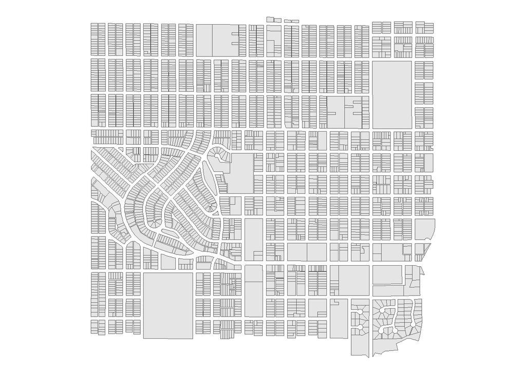

```r
ggplot(parcels) +
  geom_sf() +
  theme_void()
```

And here are the centerlines:

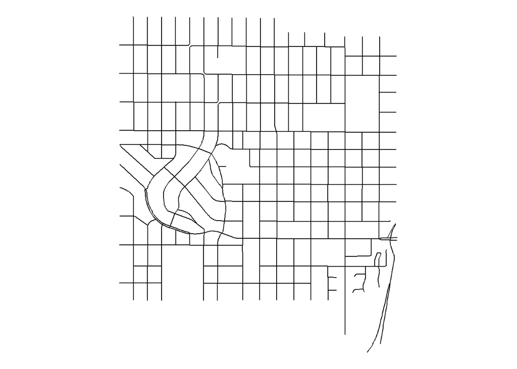

```r
ggplot(streets) +
  geom_sf() +
  theme_void()
```

## Even smaller sample

Actually, let’s start with an even smaller sample of parcels.

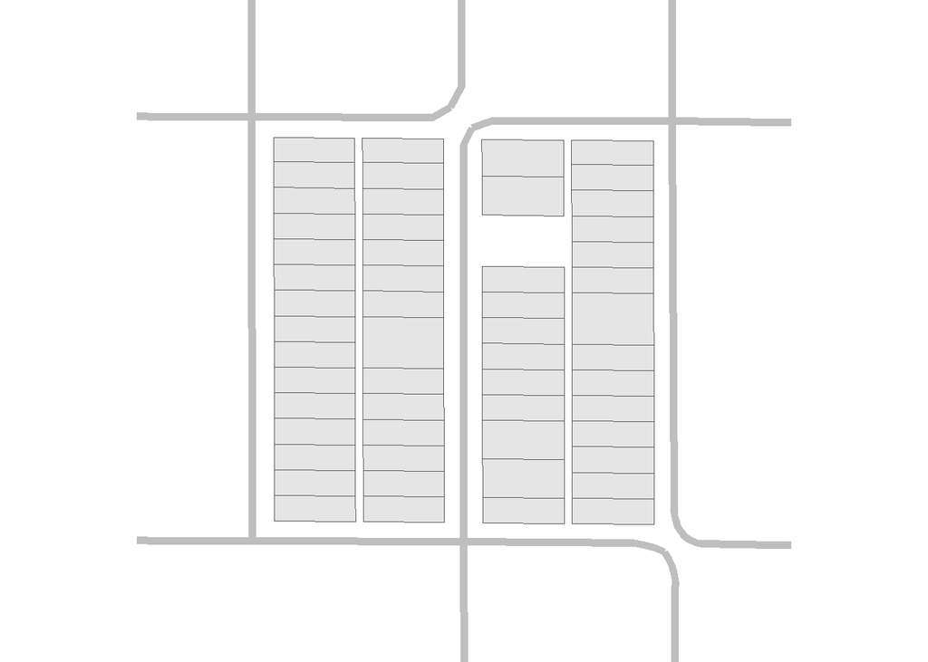

```r
fewer_parcels <- parcels[2:55,] |>
  select(PID)

fewer_parcels_bbox <- st_buffer(fewer_parcels, 50) |>
  st_bbox()

ggplot(fewer_parcels) +
  geom_sf() +
  geom_sf(data = streets,
          linewidth = 2,
          color = "gray") +
  coord_sf(xlim = c(fewer_parcels_bbox["xmin"],
                    fewer_parcels_bbox["xmax"]),
           ylim = c(fewer_parcels_bbox["ymin"],
                    fewer_parcels_bbox["ymax"])) +
  theme_void()
```

## Find label the sides

Here’s a function that will label the sides.

The front of the parcel will be the side that’s not shared with another parcel and is closest to its closest parallel street. If the closest street segment isn’t parallel (within a threshold) I’m assuming the second-closest is.

The rear will be parallel to the front, and everything that isn’t a front or a rear will be a side.

```r
label_sides <- function(my_parcels,
                        my_streets,
                        close_threshold = 3,
                        parallel_threshold = 15) {

  edges <- my_parcels |>
    st_segments(progress = FALSE)

  edges$edge_id <- seq(1:nrow(edges))

  shared <- st_equals(edges, edges, remove_self = TRUE) |>
    sapply(length)

  edges$unique = (shared == 0)

  street_segs <- st_segments(streets, progress = FALSE)

  close_street_index <- st_nn(edges, street_segs,
                            k = 2, progress = FALSE)

    close_street_index_df <- matrix(unlist(close_street_index),
                                    ncol=2,
                                    byrow=TRUE) |>
    as_tibble()

    close_street_1 <- street_segs[close_street_index_df$V1,]
  close_street_2 <- street_segs[close_street_index_df$V2,]

  edges$street_bearing_1 <- fun_bearing(st_transform(close_street_1, 2812))
  edges$street_bearing_2 <- fun_bearing(st_transform(close_street_2, 2812))
  edges$edge_bearing <- fun_bearing(st_transform(edges, 2812))

  edges_labeled <- edges |>
    mutate(angle_1 = abs(edge_bearing - street_bearing_1),
           angle_2 = abs(edge_bearing - street_bearing_2)) |>
    mutate(dist_to_para_st = ifelse(angle_1 < parallel_threshold,
                                     st_distance(edges,
                                                 close_street_1,
                                                 by_element = TRUE),
                                     st_distance(edges,
                                                 close_street_2,
                                                 by_element = TRUE))) |>
    group_by(PID) |>
    mutate(min_dist = min(dist_to_para_st)) |>
    mutate(diff = dist_to_para_st - min_dist) |>
    mutate(front = diff <= close_threshold &
             unique) |>
    mutate(nfronts = sum(front),
           front_bearings = list(edge_bearing[front])) |>
    ungroup() |>
    mutate(angle_from_front = mapply(fn_min_diff, front_bearings, edge_bearing)) |>
    mutate(side = case_when(front ~ "front",
                            angle_from_front < parallel_threshold ~ "rear",
                            TRUE ~ "side")) |>
    select(PID, side) |>
    group_by(PID, side) |>
    summarise(geometry = st_union(result))
}
```

Here’s how it looks on our small set of parcels.

The side/rear distinction might look off in a couple places - that’s because the side of one parcel is being drawn on top of the rear of another.

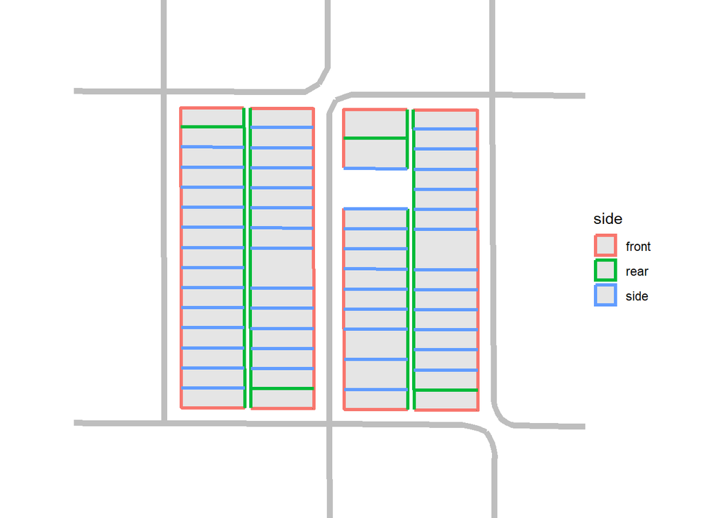

```r
edges_labeled <- label_sides(fewer_parcels, streets)

ggplot(fewer_parcels) +
  geom_sf() +
  geom_sf(data = streets,
          linewidth = 2,
          color = "gray") +
  geom_sf(data = edges_labeled,
          aes(color = side),
          linewidth = 1.2) +
  coord_sf(xlim = c(fewer_parcels_bbox["xmin"],
                    fewer_parcels_bbox["xmax"]),
           ylim = c(fewer_parcels_bbox["ymin"],
                    fewer_parcels_bbox["ymax"])) +
  theme_void()
```

Here’s the table for the first couple of those parcels.

```r
kable(edges_labeled[1:8,])
```

| PID | side | geometry |
| --- | --- | --- |
| 0902924310135 | front | LINESTRING (-93.30203 45.01… |
| 0902924310135 | rear | LINESTRING (-93.30252 45.01… |
| 0902924310136 | front | LINESTRING (-93.30203 45.01… |
| 0902924310136 | rear | LINESTRING (-93.30252 45.01… |
| 0902924310136 | side | MULTILINESTRING ((-93.30203… |
| 0902924310137 | front | LINESTRING (-93.30203 45.01… |
| 0902924310137 | rear | LINESTRING (-93.30252 45.01… |
| 0902924310137 | side | MULTILINESTRING ((-93.30203… |

## Bigger test

Now let’s hold our breath and test it on a bigger set of parcels

```r
edges_labeled_more <- label_sides(parcels, streets)

side_pal <- colorFactor(palette = brewer.pal(4, "Dark2"),
                        domain = edges_labeled_more$side)

leaflet(edges_labeled_more) |>
  addPolylines(data = streets,
               weight = 1,
               color = "black") |>
  addPolylines(color = ~side_pal(side),
               weight = 1.2,
               opacity = 0.5) |>
  addLegend("bottomright", pal = side_pal, values = ~side,
    title = "Side of parcel",
    opacity = 1) |>
  setView(lng = -93.29577, lat = 45.0026, zoom = 16)
```

[interactive chart not shown]